# Lab Name

### Exercise 5

**Question:** Create a list of `origin` airports and their rate of on-time-departure. Then visualize the distribution of on-time-departure rate across the three airports using a segmented bar plot (see below). If you could select an airport based on on time departure percentage, which NYC airport would you choose to fly out of? **Hint:** For the segmented bar plot, will need to map the `aes`thetic arguments as follows: `x = origin, fill = dep_type` and a `geom_bar()` layer. Create three plots, one with `geom_bar()` layer, one with `geom_bar(position = "fill")` and the third with `geom_bar(position = "dodge")`. Explain the difference between the three results.

```r
# Insert code for the Exercise here
nycflights <- nycflights %>%
  mutate(dep_type = ifelse(dep_delay < 5, "on time", "delayed"))

nycflights %>%
  group_by(origin) %>%
  summarise(on_time_dep_rate = sum(dep_type == "on time") / n(), n = n()) %>%
  arrange(desc(on_time_dep_rate))
```

| origin | on_time_dep_rate | n |
| --- | --- | --- |
| LGA | 0.7279229 | 10067 |
| JFK | 0.6935854 | 10897 |
| EWR | 0.6369892 | 11771 |

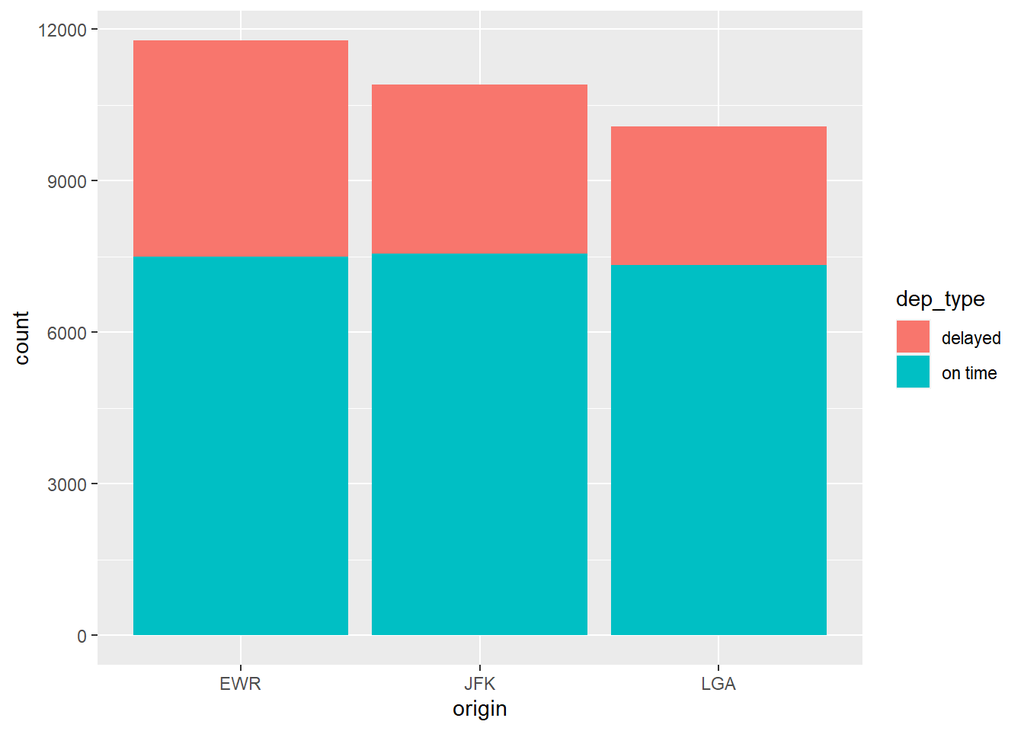

```r
nycflights |>
  ggplot(aes(x = origin, fill = dep_type)) + geom_bar()
```

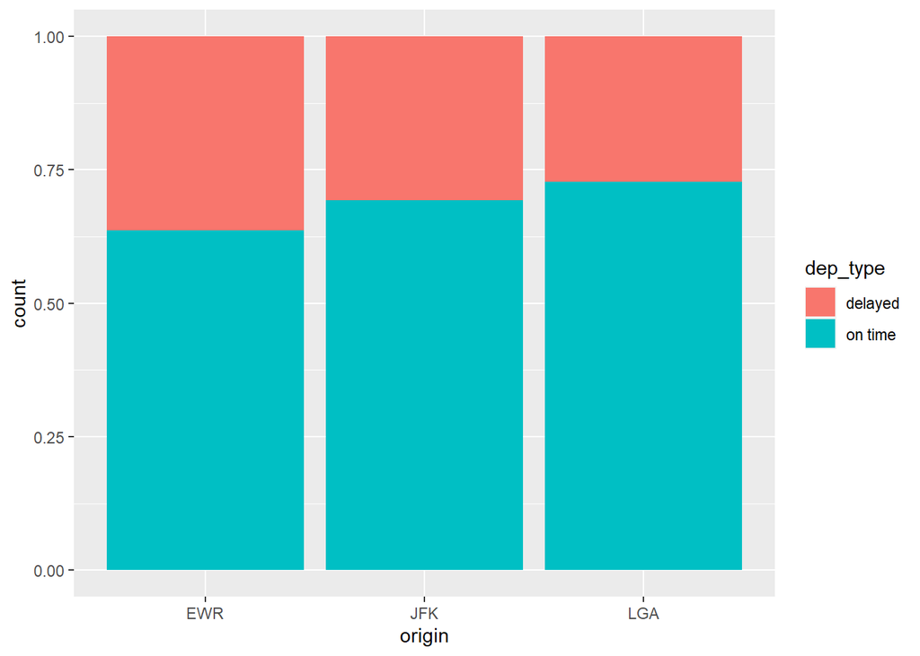

```r
nycflights |>
  ggplot(aes(x = origin, fill = dep_type)) + geom_bar(position = "fill")
```

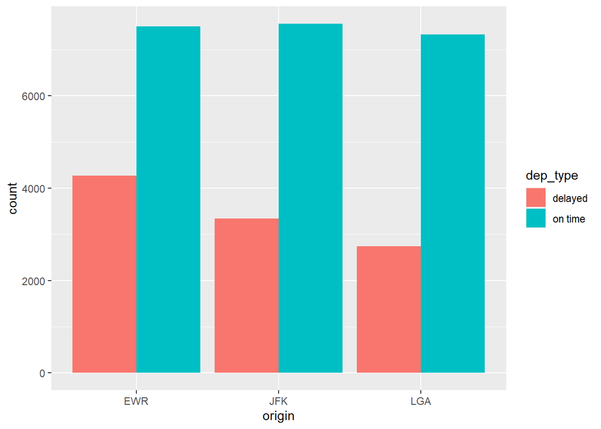

```r
nycflights |>
  ggplot(aes(x = origin, fill = dep_type)) + geom_bar(position = "dodge")
```

### Exercise 6

**Question:** Mutate the data frame so that it includes a new variable that contains the average speed, `avg_speed` traveled by the plane for each flight (in mph, or if you are brave, in km/h). Now make a scatter plot of `distance` vs. `avg_speed`. Think carefully which of the two variables is the predictor (on the `x-axis`) and which is the outcome variable (on the `y-axis`) and explain why you made this choice. Describe the relationship between average speed and distance.

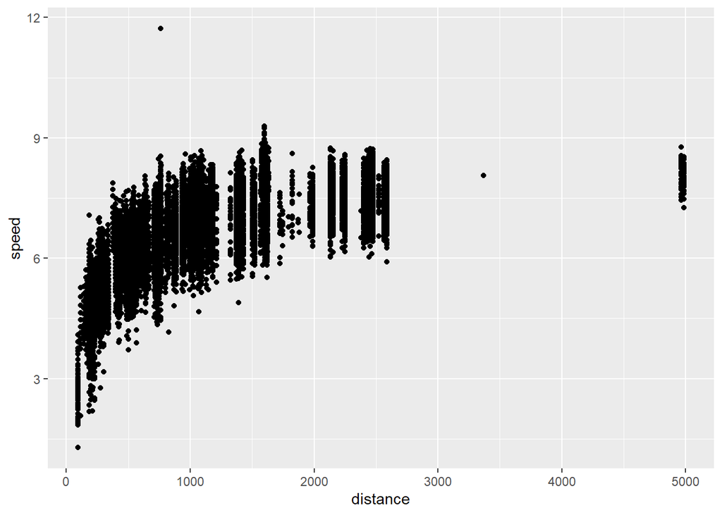

```r
# Insert code for the Exercise here
nycflights |>
  mutate(speed = distance / air_time) |>
  ggplot(aes(distance, speed)) +
  geom_point()
```

### Exercise 7

**Question:** Replicate the following plot and determine what is the cutoff point for the latest departure delay where you can still have a chance to arrive at your destination on time.

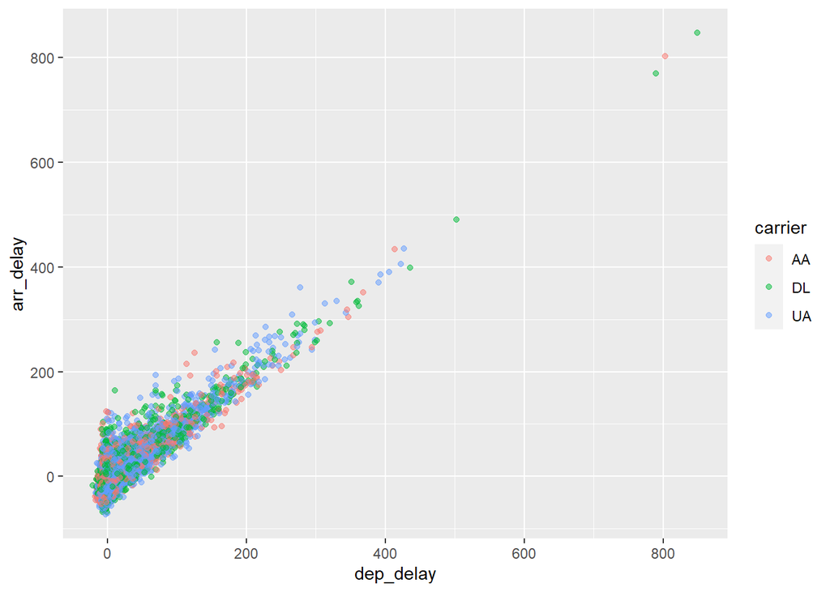

```r
# Insert code for the Exercise here
nycflights %>%
  filter(carrier == "AA" | carrier == "DL" | carrier == "UA") |>
ggplot(aes(x = dep_delay, y = arr_delay, color = carrier)) +
  geom_point(alpha = .5)
```